# Logistic Population growth

Beth Babcock

2026-09-01

Open ggplot

```r
library(tidyverse)
theme_set(theme_bw(base_size = 14))
```

### How to model density dependence and carrying capacity?

Define $K$, carrying capacity as the number of animals a habitat can support.

Define $r_m$ as the intrinsic population growth rate. The realized growth rate $r$ may be lower due to density dependent processes.

### Oversimplified idea 1.

Assume that the growth rate does not change with density, but all animals after animal K die.

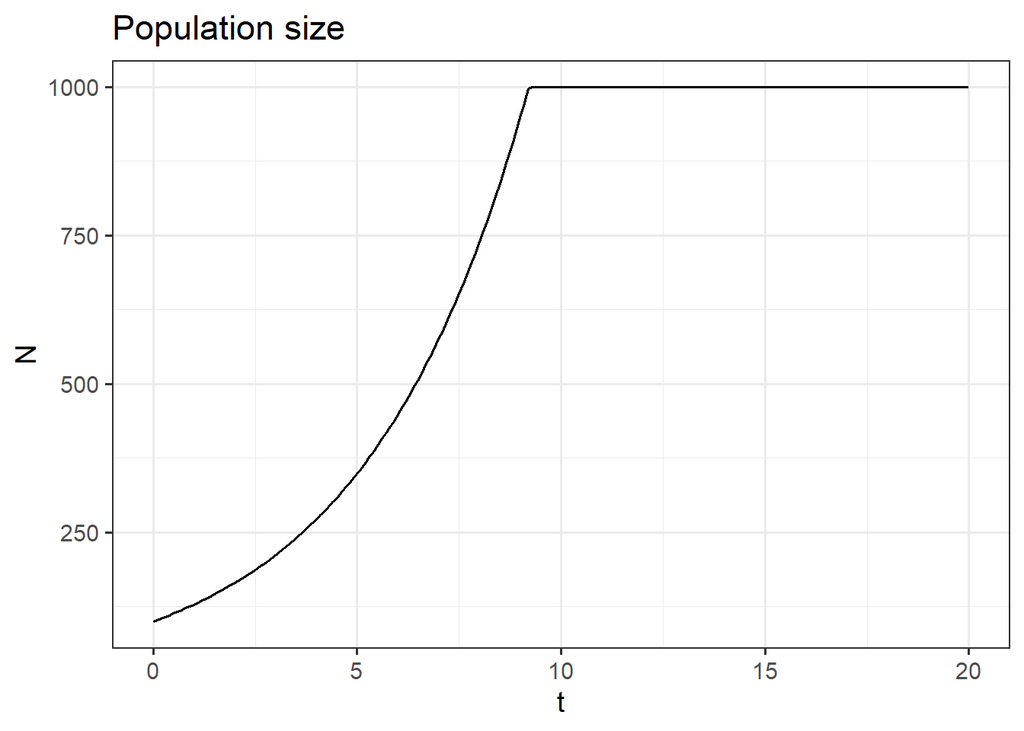

```r
rm<-0.25
K<-1000
N0<-100
Population<-data.frame(t=seq(0,20,0.1))
Population$N<-pmin(N0*exp(rm*Population$t),K)

ggplot(Population,
       aes(x=t,y=N))+
  geom_line()+
  ggtitle("Population size")
```

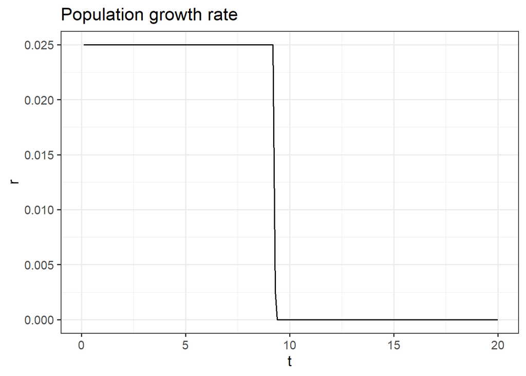

```r
Population$r<-c(NA,log(Population$N[2:nrow(Population)]/Population$N[1:(nrow(Population)-1)]))
ggplot(Population,
       aes(x=t,y=r))+
  geom_line()+
  ggtitle("Population growth rate")
```

### Oversimplified idea 2.

Realized $r$ decreases linearly with abundance

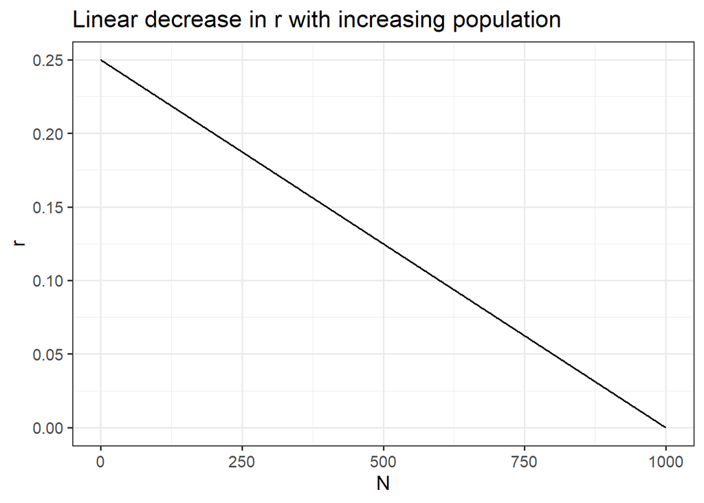

```r
ggplot(data.frame(N=0:1000,
       r=(1-(0:1000)/1000)*rm),
       aes(x=N,y=r))+
         geom_line()+
  ggtitle("Linear decrease in r with increasing population")
```

$$r=r_m(1-N/K)$$

so that

$$\delta N/\delta t=r_m(1-N/K)N$$
In continuous time, this integrates to:

$$N_t=\frac{K}{1+\frac{(K-N_0)}{N_0}
e^{-r_m t}}$$
We can make a function for ease of calculation

```r
logisticN<-function(rm,K,N0,tt) {
  Nt<-K/(1+(K-N0)*exp(-(rm*tt))/N0)
  Nt
}
tt=50
N0=1000
logisticN(rm,K,N0,tt)
```

```
## [1] 1000
```

Now use the function to make a data frame including numbers per year.

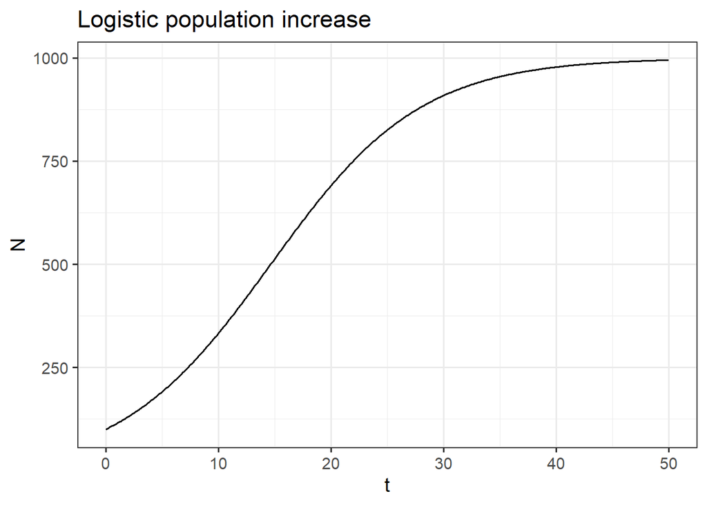

```r
rm<-0.15
K<-1000
N0<-100
Population<-data.frame(t=seq(0,50,0.1))
Population$N<-logisticN(rm=rm,K=K,N0=N0,tt=Population$t)

ggplot(Population,
       aes(x=t,y=N))+
  geom_line()+
  ggtitle("Logistic population increase")
```

This is logistic population growth, and is a commonly used model for population dynamics for many kinds of species.

If the population starts out above K, it will decline to K

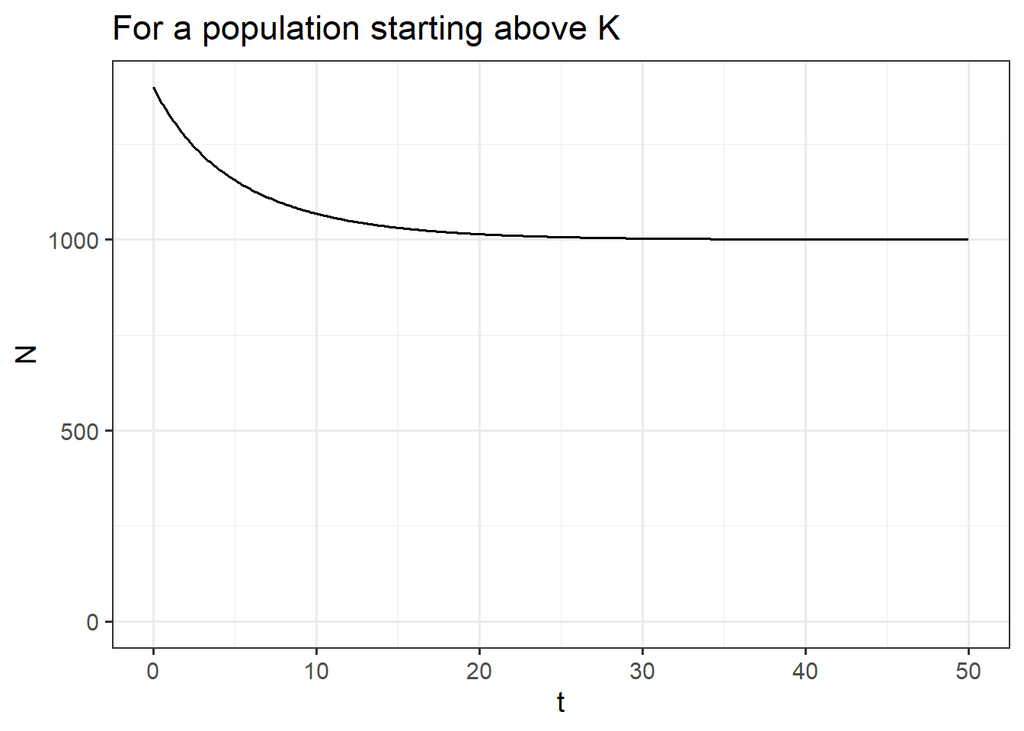

```r
rm<-0.15
K<-1000
N0<-1400
Population<-data.frame(t=seq(0,50,0.1))
Population$N<-logisticN(rm=rm,K=K,N0=N0,tt=Population$t)

ggplot(Population,
       aes(x=t,y=N))+
  geom_line()+
  ylim(c(0,N0))+
  ggtitle("For a population starting above K")
```

If it starts at K, then it will stay there.

### Yield curve and MSY

Make a plot of the increase as a function of abundance.

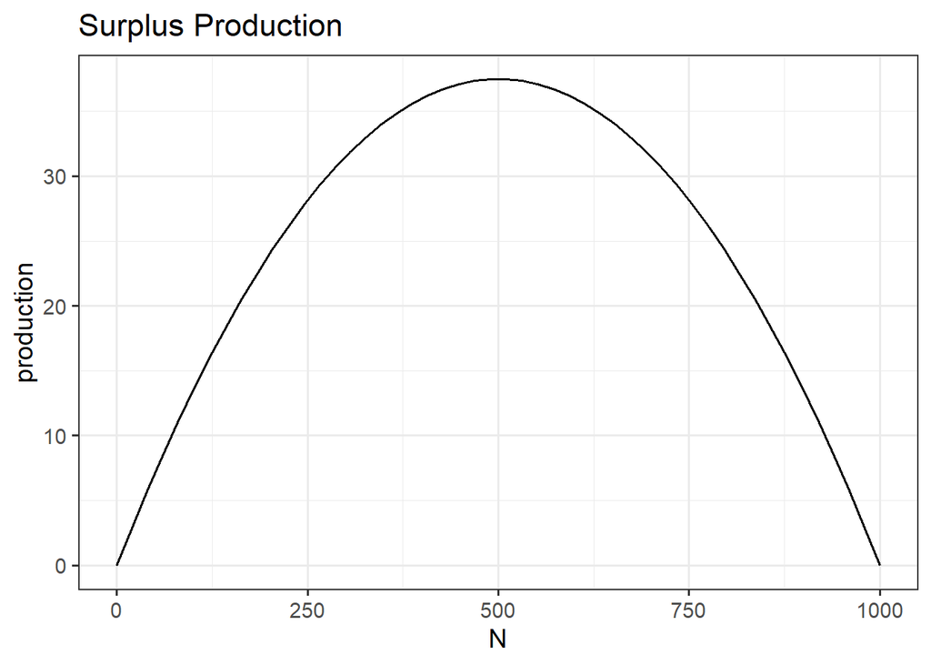

```r
production<-data.frame(N=seq(0,K,length=50))
production$production=rm*(1-production$N/K)*production$N
ggplot(production,aes(x=N,y=production))+
  geom_line()+
  ggtitle("Surplus Production ")
```

### Discrete time version

For an annual time step, this simplifies to

$$N_{t+1}=N_t+r (1/N_t/K) N_t$$
As a function:

```r
logisticNdiscrete<-function(rm,K,Nt) {
  Nt+rm*(1-Nt/K)* Nt
}
logisticNdiscrete(rm=0.25,K=1000,Nt=45)
```

```
## [1] 55.74375
```

To calculate the numbers in each year, start at $N_0$, and use the discrete time logistic to calculate the numbers in each following year.

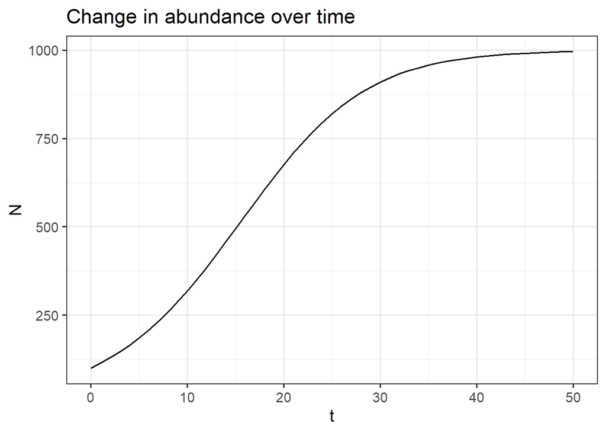

```r
rm<-0.15
K<-1000
N0<-100
Population<-data.frame(t=seq(0,50),
                       N=NA)
Population$N[1]<-N0
for(i in 2:nrow(Population)) {
 Population$N[i]<-logisticNdiscrete(rm=rm,K=K,Nt=Population$N[i-1])
}

ggplot(Population,
       aes(x=t,y=N))+
  geom_line()+
  ggtitle("Change in abundance over time")
```

What happens if there is a catastrophic mortality event, like a hurricane?

The discrete time version makes it easy to model. We can write the equation as

$$N_{t+1}=N_t+r (1/N_t/K) N_t -
C_t$$
Where $C_t$ is the number of animals killed in the catastrophe. You can see from the equation that the number of animals in time $t+1$ will be less than the number of animals that are produced by the population $r (1/N_t/K) N_t$ That number is called the surplus production, and it is the amount of new population that can be generate from births minus deaths given the current population.

You may have seen this model before in fisheries, where it is called the Schaefer Surplus Production model, and the $C_t$ stands for the catch in each year. In fisheries, the equation is often calculated in biomass rather than numbers.

```r
Population<-data.frame(t=seq(0,50),
                       C=0,
                       N=NA)
Population$C[Population$t==10]<-90
```

For convenience, add the catch/catastrophe to our function

```r
logisticNdiscreteWithC<-function(rm,K,Nt,Ct=0) {
  Nt+rm*(1-Nt/K)* Nt -Ct
}
logisticNdiscreteWithC(rm=0.25,K=1000,Nt=45)
```

```
## [1] 55.74375
```

Plot with a disaster event

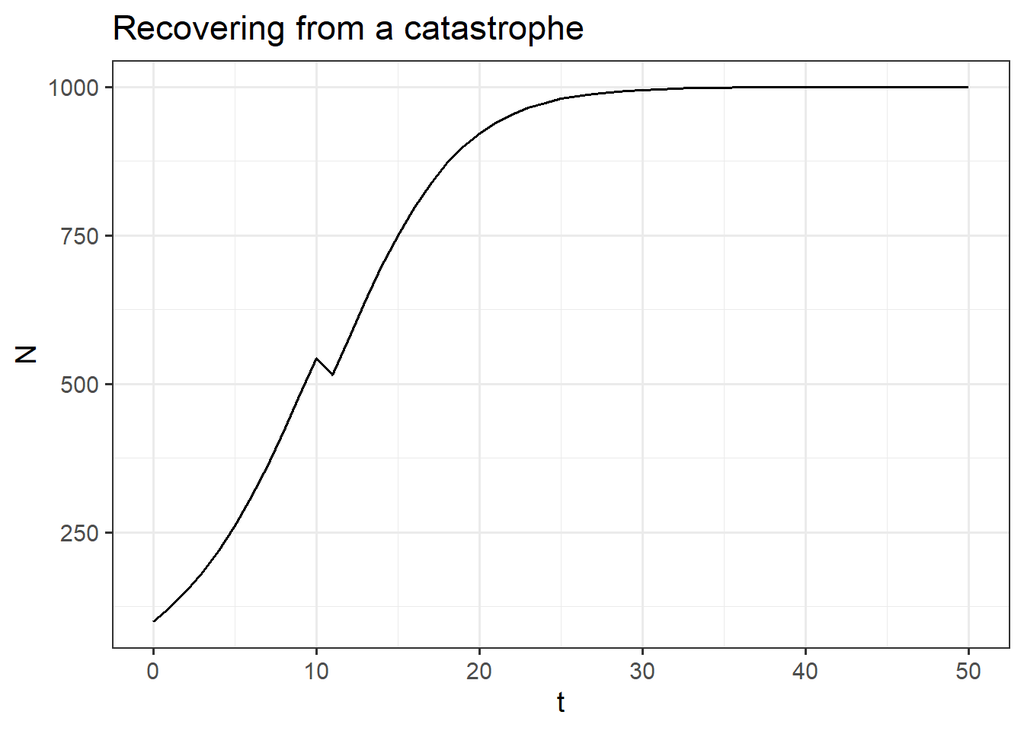

```r
rm<-0.25
K<-1000
N0<-100
Population$N[1]<-N0
for(i in 2:nrow(Population)) {
 Population$N[i]<-logisticNdiscreteWithC(rm=rm,K=K,
                                    Nt=Population$N[i-1],
                                    Ct=Population$C[i-1])
}

ggplot(Population,
       aes(x=t,y=N))+
  geom_line()+
  ggtitle("Recovering from a catastrophe"  )
```

### Fitting a model with maximum likelihood

### MLE fit of the swordfish surplus production model

Swordfish data

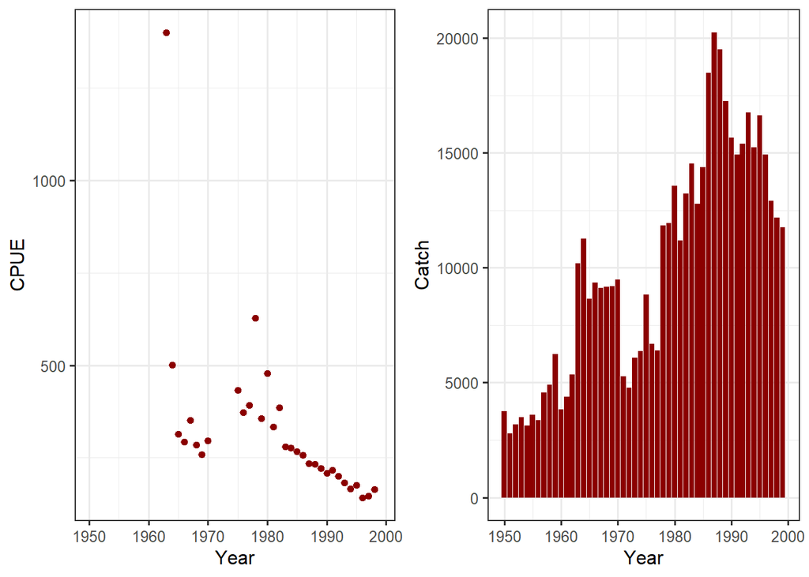

```r
swordfish<-read.csv("Swordfish.csv")
swo1<-ggplot(swordfish,aes(x=Year,y=CPUE))+
      geom_point(color="darkred")+theme_bw(base_size=12)
swo2<-ggplot(swordfish,aes(x=Year,y=Catch))+
      geom_col(fill="darkred")+theme_bw(base_size=12)
gridExtra::grid.arrange(swo1,swo2,ncol=2)
```

Write function for minimization of -LL

```r
getNegLogLike<-function(theta,data) {
  B<-NULL
  LL<-NULL
  logpredI<-NULL
  K<-exp(theta["logK"])
  B[1]<-K
  for(y in 2:nrow(data)) {
     B[y]<-max(c(B[y-1]+theta["r"]*B[y-1]*(1-B[y-1]/K)-
                   data$Catch[y-1],0.0001))
  }
  for(y in 1:nrow(data)) {
    logpredI[y]<-log(B[y]*theta["q"])
    LL[y]<-dlnorm(data$CPUE[y],logpredI[y],theta["sigma"],log=TRUE)
  }
  -sum(LL,na.rm=TRUE)
}

getNegLogLike(theta=c(r=0.8,logK=log(90000),q=0.001,sigma=0.3),
              data=swordfish)
```

```
## [1] 562.305
```

Fit the model

```r
modFit<-optim(par=c(r=0.8,logK=log(90000),q=0.001,sigma=0.3),
              fn=getNegLogLike,
              data=swordfish,
              lower=c(r=0.01,K=10,q=0.0000001,sigma=0.0001),
              upper=c(r=4,K=1000000,q=1,sigma=10),
              method="L-BFGS-B",
              control=list(trace=TRUE))
modFit$par
```

```
##            r         logK            q        sigma
##  0.798782042 11.230539562  0.006235967  0.298333306
```

```r
exp(modFit$par["logK"])
```

```
##     logK
## 75398.27
```

Plot the fit

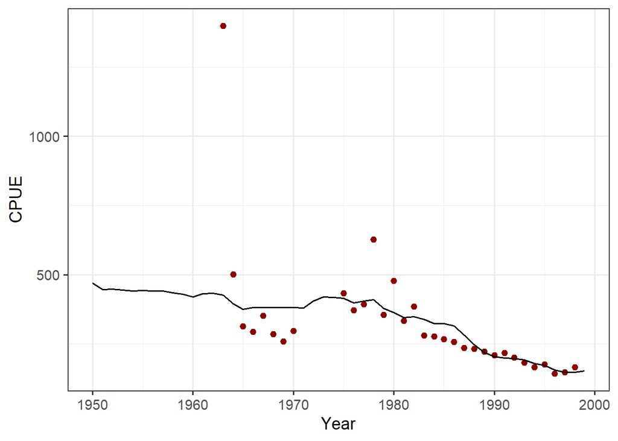

```r
swordfish$Biomass[1]<-exp(modFit$par["logK"])
for(y in 2:nrow(swordfish)) {
  swordfish$Biomass[y]<-logisticNdiscreteWithC(rm=modFit$par["r"],
                                          K=exp(modFit$par["logK"]),
                                    Nt=swordfish$Biomass[y-1],
                                    Ct=swordfish$Catch[y-1])
}
swordfish$Predicted.CPUE<-modFit$par["q"]*swordfish$Biomass
ggplot(swordfish,aes(x=Year,y=CPUE))+
      geom_point(color="darkred")+
  geom_line(aes(y=Predicted.CPUE))
```

Run the shiny app and answer all the questions.

https://elizabeth-babcock.shinyapps.io/ProductionModelDemo3/